```python
import numpy as np
import matplotlib.pyplot as plt
import random
```

# Gillespie

### One reaction

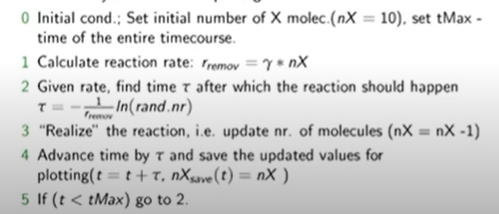

### Two reactions

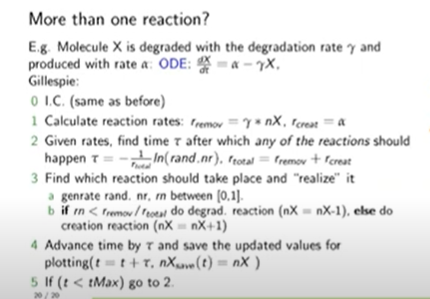

```python
# SOUTION 2, that can be easy generalized to loops if have many reactions as in e.g. Oosawa model
#Parameters
k=5 #rate of creation
tauX = 2 #decay time
tmax = 40


# 0. Set initial conditions
nX = 1
t = 0

#make lists for saving the values
Xt = [nX]
tt = [t]

#run Gillspie
while t <= tmax:
    #1. update rates
    prod_X = k #creation rate
    deg_X = nX/tauX #removal rate

    #total rate,
    total_rate = prod_X + deg_X

    #2. time to next reaction
    rn1 = random.random()
    tau = -1/total_rate*np.log(rn1) #the time to next reaction , from exponential distribution, rn = 1-exp(-total_rate*tau), or because 1-rn is also a rn, rn = exp(-total_rate*tau)
    #3. find wich reaction (production or degradation) will take place
    rn2  = random.random()
    done = False #This variable will be used to track

    if(rn2 < prod_X/total_rate):
        nX = nX + 1
        done = True

    if (not done):
        if (rn2 < (prod_X + deg_X)/total_rate): # here checking if degradation reaction should happen. Could have just done with else in previous if sttement
            nX = nX - 1
            done = True

    #4. advance in time with tau
    t = t + tau
    # save values for plotting
    Xt.append(nX)
    tt.append(t)
```

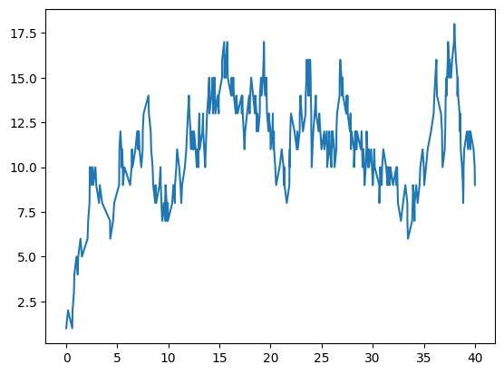

```python
plt.plot(tt,Xt)
```

## Question

“When and what can physics/models tell you something from the data on protein aggregates?”

###### Stochastic simulations of the protein aggregation

1. Write code simulating master equations for nucleation and aggregation events (Oosawa

model) using Gillespie approach.

```
a. Test your results by plotting how number of polymers, f(t,j), of size j change with time, t, for j=nc and some other larger j.

b. If not familiar with Gillespie algorithm, see recorded lecture and sample code in Python under Module 1
```

We are given:

1. The initial amount of monomers $m_0$.
2. The nucleation number $n_c$.
3. The rate of nucleation $k_c$.
4. The rate of association $K_a$.

$f(t,j)$ is the number of aggregates of size $j$ at time $t$. Then, the differential equation for the process is:

$$\frac{df(t,j)}{dt} = k_n(m(t))^{n_c} + k_a*m(t)*[f(t,j-1) - f(t,j)] $$

```python
def Mt(f):
    " Calculate the total mass of polymers"
    return np.sum(np.arange(len(f))*f)

def calc_assoc_rates(ka,mt,f):
    '''For every size j, calculat the rate at which new polymers of length
    are created because of association of a polymer of length j-1.

    Returns an array with the association rates for each j.'''

    assoc_rates = np.zeros(len(f))
    for j in range(1,len(f)):
        assoc_rates[j] = ka*mt*f[j-1]

    return(assoc_rates)


def run_gillespie(m0=100,  kn=1e-5,ka=1e-3,nc=3,tmax=200,jmax=10):
    t=0

    f = np.zeros(jmax)
    ft = [np.copy(f)]
    tt = [t]
    Mtt = [Mt(f)]

    total_rate = 1
    while t <= tmax and total_rate > 0:
        #1. update rates
        mt = (m0 - Mt(f))  # number of remaining monomers.
        nucl_rate = kn*mt**nc

        assoc_rates = calc_assoc_rates(ka, mt, f)


        total_rate = nucl_rate + np.sum(assoc_rates)
        if total_rate <= 0:
            print("total_rate = ", total_rate)
            break

        #2. time to next reaction.
        rn1 = random.random()
        tau = -1/total_rate*np.log(rn1)

        #3. find which reaction to do.
        rn2 = random.random()

        done = False

        if(rn2 < nucl_rate/total_rate):
            f[nc] = f[nc] + 1 # creation reaction
            done = True

        else:
            current_rate = nucl_rate
            for jj in range(nc+1,jmax):
                current_rate = current_rate + assoc_rates[jj]
                if (not done) and (rn2 < current_rate / total_rate):
                    f[jj] = f[jj]+1
                    f[jj-1] = f[jj-1]-1
                    done = True
                    break

        #4. advance time
        t = t+tau

        #5. save values
        ft.append(np.copy(f))
        Mtt.append(Mt(f))
        tt.append(t)

    return(tt,np.array(ft),Mtt)
```

```python
def plot_mt(tt,Mtt,lim=100):
    plt.plot(tt,Mtt)
    plt.xlabel("Time")
    plt.ylabel("M")
    plt.ylim(0,lim)
    plt.show()

def plot_ft_history(tt,ft,n=1):
    t_idx = 1# index
    colors = plt.cm.Greens(np.linspace(0, 1, len(tt)))

    for t_idx in range(len(tt)):
        if t_idx % n == 0:
            color = colors[t_idx]
            plt.plot(ft[t_idx,:],color = color,alpha=t_idx/len(tt))

    plt.xlabel('j, polymer length')
    plt.ylabel('f(j), number of polymers of lenght j')
    plt.show()

def plot_ft(ft):
    plt.plot(ft[-1])
    plt.xlabel('j, polymer length')
    plt.ylabel('f(j), number of polymers of lenght j')
    plt.show()
```

```
total_rate =  0.0
```

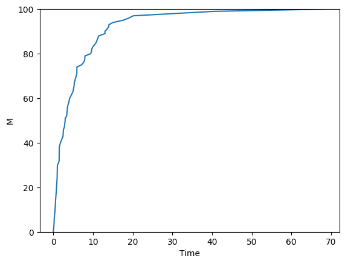

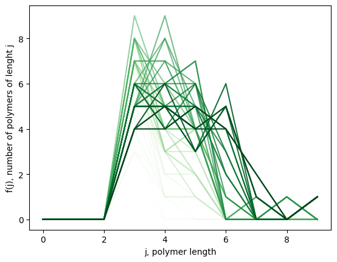

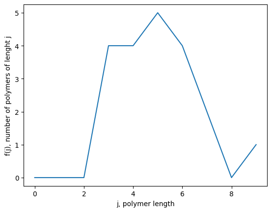

```python
tt,ft,Mtt = run_gillespie(m0=100,
                          kn=1e-5,
                          ka=5e-3,
                          nc=3,
                          tmax=500,
                          jmax=10)
plot_mt(tt,Mtt)
plt.show()
plot_ft_history(tt,ft)
plot_ft(ft)
```

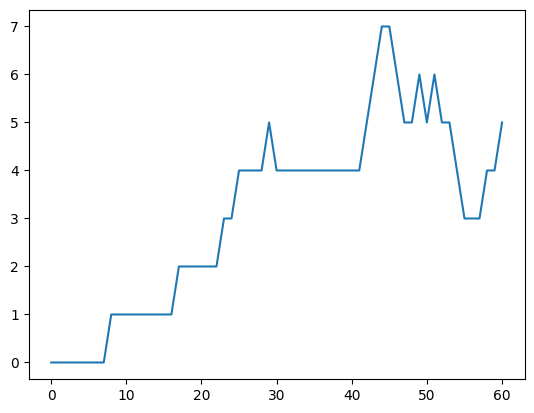

```python
plt.plot(ft[:,5])
```

### 3.

Investigate how adding dissociation term affects the aggregation characteristics (e.g. what happens with the distribution of aggregate sizes at long times. What happens as you change association, dissociation and nucleation rates? What are the meaningful constraints for the parameters to obtain steady state? First develop a feeling by looking at equations, then run simulations to test).

**Dissociation:** Substract one monomer from a polymer. $$T_{diss} = 2 k_d [f(t,j+1)-f(t,j)]$$

Then, the equations look like: $$\dfrac{dP(t)}{dt} = k_n m(t)^{n_c}$$ $$\dfrac{dM(t)}{dt} = (k_a m(t) - 2k_d) P(t) + n_c k_n m(t)^{n_c}$$

```python
def Mt(f):
    " Calculate the total mass of polymers"
    return np.sum(np.arange(len(f))*f)


def calc_assoc_rates(ka,mt,f):
    '''For every size j, calculat the rate at which new polymers of length
    are created because of association of a polymer of length j-1.

    Returns an array with the association rates for each j.'''

    assoc_rates = np.zeros(len(f))
    for j in range(1,len(f)):
        assoc_rates[j] = ka*mt*f[j-1]

    return(assoc_rates)

def calc_dissoc_rates(kd,f):
    '''For every size j, calculat the rate at which new polymers of length
    are created because of association of a polymer of length j-1.

    Returns an array with the association rates for each j.'''

    dissoc_rates = np.zeros(len(f))
    for j in range(0,len(f)-1):
        dissoc_rates[j] = 2*kd*f[j+1]

    return(dissoc_rates)


def run_gillespie_d(m0=100,  kn=1e-5,ka=1e-3,kd=2e-1,nc=3,tmax=200,jmax=10):
    t=0

    f = np.zeros(jmax)
    ft = [np.copy(f)]
    tt = [t]
    Mtt = [Mt(f)]

    total_rate = 1
    while t <= tmax and total_rate > 0:
        #1. update rates
        mt = (m0 - Mt(f))
        nucl_rate = kn*mt**nc

        assoc_rates = calc_assoc_rates(ka, mt, f)
        dissoc_rates = calc_dissoc_rates(kd,f)




        total_rate = nucl_rate + np.sum(assoc_rates) + np.sum(dissoc_rates)

        if total_rate <= 0:
            print("total_rate = ", total_rate)
            break

        #2. time to next reaction.
        rn1 = random.random()
        tau = -1/total_rate*np.log(rn1)

        #3. find which reaction to do.
        rn2 = random.random()

        done = False

        if(rn2 < nucl_rate/total_rate):
            f[nc] = f[nc] + 1 # creation reaction
            done = True

        else:
            current_rate = nucl_rate
            for jj in range(nc+1,jmax):
                current_rate = current_rate + assoc_rates[jj]
                if (not done) and (rn2 < current_rate / total_rate):
                    f[jj] = f[jj]+1
                    f[jj-1] = f[jj-1]-1
                    done = True
                    break

            for jj in range(nc,jmax-1):
                current_rate = current_rate + dissoc_rates[jj]
                if (not done) and (rn2 < current_rate / total_rate):
                    f[jj] = f[jj]+1
                    f[jj+1] = f[jj+1]-1
                    done = True
                    break

        #4. advance time
        t = t+tau

        #5. save values
        ft.append(np.copy(f))
        Mtt.append(Mt(f))
        tt.append(t)

    return(tt,np.array(ft),Mtt)
```

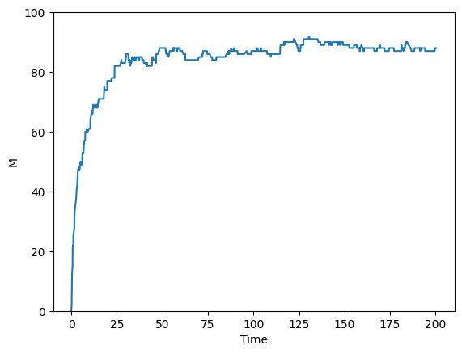

```
88.0
```

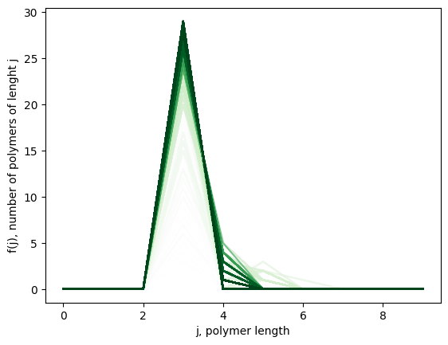

```python
random.seed(1)

tt,ft,Mtt = run_gillespie_d(m0=100,
                          kn=1e-5,
                          ka=1e-3,
                          kd=0.1,
                          nc=3,
                          tmax=200,
                          jmax=10)
plot_mt(tt,Mtt,100)
print(Mtt[-1])
plt.show()
plot_ft_history(tt,ft)
```

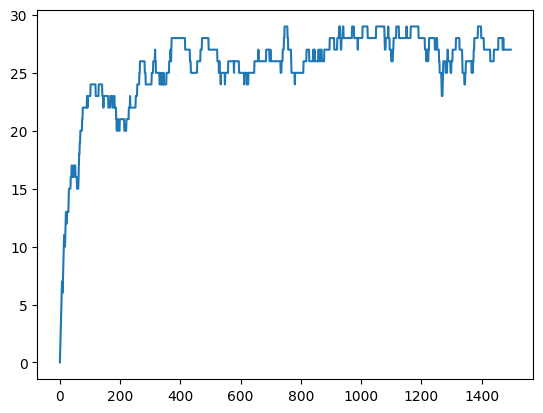

```python
plt.plot(ft[:,3])
```

### 4. Add fragmentation term

Fragmentation:

$$T_{frag} = 2k_f \sum_{k=j+1}^{\infty} f(t,k) - k_f(j-1)f(t,j) $$

.

Then, the equations become:

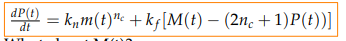

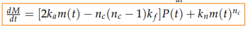

```python
def Mt(f):
    " Calculate the total mass of polymers"
    return np.sum(np.arange(len(f))*f)


def calc_assoc_rates(ka,mt,f):
    '''For every size j, calculate the rate at which new polymers of length
    are created because of association of a polymer of length j-1.

    Returns an array with the association rates for each j.'''

    assoc_rates = np.zeros(len(f))
    for j in range(1,len(f)):
        assoc_rates[j] = ka*mt*f[j-1]

    return(assoc_rates)

def calc_dissoc_rates(kd,f):
    dissoc_rates = np.zeros(len(f))
    for j in range(0,len(f)-1):
        dissoc_rates[j] = 2*kd*f[j+1]

    return(dissoc_rates)


def calc_fragm_rates(kf,f):
    fragm_rates = np.zeros(len(f))

    for j in range(1,len(f)):
        fragm_rates[j] = kf*(j-1)*f[j]

    return(fragm_rates)





def run_gillespie_f(m0=100,  kn=1e-5,ka=1e-3,kd=1e-1,kf=1e-1,nc=3,tmax=200,jmax=10):
    t=0

    f = np.zeros(jmax)
    ft = [np.copy(f)]
    tt = [t]
    Mtt = [Mt(f)]

    total_rate = 1
    while t <= tmax and total_rate > 0:
        #1. update rates
        mt = (m0 - Mt(f))
        nucl_rate = kn*mt**nc

        assoc_rates = calc_assoc_rates(ka, mt, f)
        dissoc_rates = calc_dissoc_rates(kd,f)
        fragm_rates = calc_fragm_rates(kf,f)




        total_rate = nucl_rate + np.sum(assoc_rates) + np.sum(dissoc_rates) + np.sum(fragm_rates)

        if total_rate <= 0:
            print("total_rate = ", total_rate)
            break

        #2. time to next reaction.
        rn1 = random.random()
        tau = -1/total_rate*np.log(rn1)

        #3. find which reaction to do.
        rn2 = random.random()

        done = False

        if(rn2 < nucl_rate/total_rate):
            f[nc] = f[nc] + 1 # creation reaction
            done = True

        else:
            current_rate = nucl_rate
            for jj in range(nc+1,jmax):
                current_rate = current_rate + assoc_rates[jj]
                if (not done) and (rn2 < current_rate / total_rate):
                    f[jj] = f[jj]+1
                    f[jj-1] = f[jj-1]-1
                    done = True
                    break

            for jj in range(nc,jmax-1):
                current_rate = current_rate + dissoc_rates[jj]
                if (not done) and (rn2 < current_rate / total_rate):
                    f[jj] = f[jj]+1
                    f[jj+1] = f[jj+1]-1
                    done = True
                    break

            for jj in range(nc,jmax):
                current_rate = current_rate + fragm_rates[jj]
                if (not done) and (rn2 < current_rate / total_rate):
                    f[jj] = f[jj]-1
                    cut = random.randint(1,jj-1)
                    if cut >= nc:
                        f[cut] = f[cut]+1
                    if jj-cut >= nc:
                        f[jj-cut] = f[jj-cut]+1

                    done=True
                    break


        #4. advance time
        t = t+tau

        #5. save values
        ft.append(np.copy(f))
        Mtt.append(Mt(f))
        tt.append(t)

    return(tt,np.array(ft),Mtt)
```

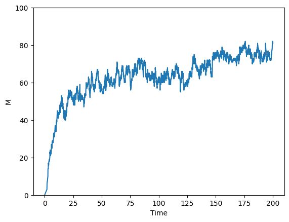

```
81.0
```

```python
random.seed(1)

tt,ft,Mtt = run_gillespie_d(m0=100,
                          kn=1e-6,
                          ka=1e-2,
                          kd=0.5,
                          nc=3,
                          tmax=200,
                          jmax=10)
plot_mt(tt,Mtt,100)
print(Mtt[-1])
plt.show()
# plot_ft_history(tt,ft)
```

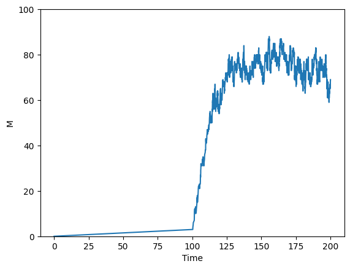

```
69.0
```

```python
random.seed(1)

# total_Mtt = Mtt*0
# for j in range(1000):
tt,ft,Mtt = run_gillespie_f(m0=100,
                          kn=2e-8,
                          ka=3e-2,
                          kd=0.1,
                          kf=.1,
                          nc=3,
                          tmax=200,
                          jmax=10)

#     total_Mtt += np.array(Mtt)/1000

plot_mt(tt,Mtt,100)
print(Mtt[-1])
plt.show()
# plot_ft_history(tt,ft,5)
# plot_ft(ft)
```

```python
print(len(tt))
```

```
1870
```

```python
random.seed(1)

# total_Mtt = Mtt*0
# for j in range(1000):
tt,ft,Mtt = run_gillespie_f(m0=100,
                          kn=2e-8,
                          ka=3e-2,
                          kd=0.1,
                          kf=.1,
                          nc=3,
                          tmax=200,
                          jmax=10)

#     total_Mtt += np.array(Mtt)/1000

plot_mt(tt,Mtt,100)
print(Mtt[-1])
plt.show()
# plot_ft_history(tt,ft,5)
# plot_ft(ft)



Mtt_n = []

j = 0
for i in range(len(tt)):
    step_size = len(tt)/1000
    if i > step_size*j:
        j+=1
#         print(step_size)
#         print(step_size*j)
        Mtt_n.append(Mtt[i])

len(Mtt_n)
```

[output not shown]

```
1000
```

# Deterministic Finke Watzky 2 step model

```python
from scipy.integrate import solve_ivp



k1 = 0.1
k2 = 0.05
tmax = 100
delta_t = tmax/1000

def solve(ts,k1,k2,A0=1):
    indxs = ts//delta_t
    indxs = indxs.astype(int)

    val = 1
    vals = []
    for i in range(indxs[-1]+1):

        val += (-k1*val - k2*val*(A0-val))*delta_t

        if i in indxs:
            vals.append(val)

    return(1-np.array(vals))
```

```python
ts = np.linspace(0,tmax,100)

Bs = solve(ts,k1,k2)
```

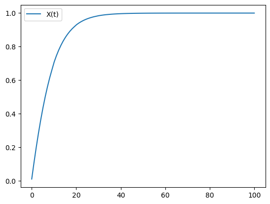

```python
plt.plot(np.linspace(0,tmax,100), Bs)
plt.legend(['X(t)'])
```

```python
# Fitting to data fig 3
ts3 = [0    ,
9.7   ,
19.72 ,
37.82 ,
53.99 ,
72.41 ,
91.81 ,
112.5 ,
132.87,
152.26,
171.01,
202.37,
232.76,
260.56,
292.56]

Bss3 = [0.11,
0.23,
0.31,
0.61,
1.23,
1.32,
1.43,
1.48,
 1.5,
 1.47,
 1.41,
 1.47,
 1.45,
 1.52,
 1.5]


ts9 =[0 ,
15.06 ,
41.03 ,
50.32 ,
68.91 ,
78.21 ,
95.83 ,
101.6 ,
121.79,
151.6]

Bss9 = [0.28,
0.57,
12.34,
18.78,
36.15,
43.01,
53.65,
59.12,
 67.8,
81.54]
```

```
0.001932371120404763 0.0378100283535095
```

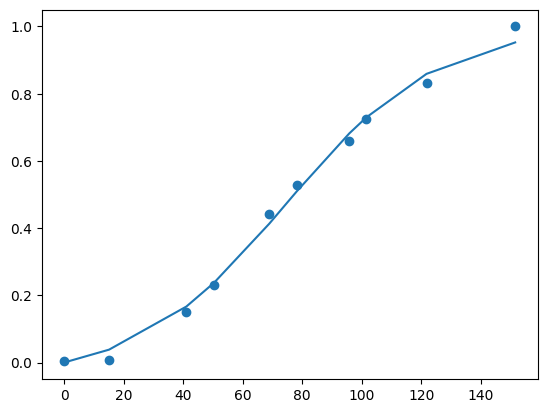

```python
import scipy as sc

res = sc.optimize.curve_fit(solve,ts9,Bss9/np.max(Bss9),
                            [0.1,0.05],bounds=[(0,0),(1,1)])
res

k1,k2 = res[0]
print(k1,k2)
Bs_sim = solve(np.array(ts9),k1,k2)
plt.scatter(ts9,Bss9/np.max(Bss9))
plt.plot(ts9,np.array(Bs_sim))
```

```
0.00661998552688654 0.0524211128373635
```

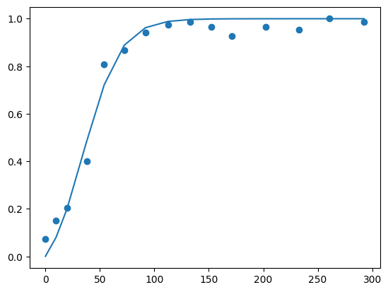

```python
import scipy as sc

res = sc.optimize.curve_fit(solve,ts3,Bss3/np.max(Bss3),
                            [0.1,0.05],bounds=[(0,0),(1,1)])
res

k1,k2 = res[0]
print(k1,k2)
Bs_sim = solve(np.array(ts3),k1,k2)
plt.scatter(ts3,Bss3/np.max(Bss3))
plt.plot(ts3,np.array(Bs_sim))
```

**The deterministic Finke-Watzky and stochastic models are very different. What are the cons and pros of each? When would one be favored over the other?**

**Finke Watzky**:

Pros: Less parameters, easier to fit to data, easier to simulate (just solving a differential equation with initial conditions).

Cons: Doesn't tell you much about the mechanics of the aggregations.

**Stochastic:**

Pros: Easy to understand where everything comes from, since it is defined mechanistically.

Cons: Many parameters and hart to fit to data.